# Bechdel Test Exploratory Data Analysis

Author

Simal Sami

## Bechdel Test Data EDA

```r
#! include: false
#! warning: false
#! message:false
#! echo: false
library(tidyverse)
library(ggthemes)
library(GGally)
library(skimr)
library(patchwork)
library(RColorBrewer)
library(ggplot2)
library(ggpattern)
library(knitr)

theme_set(theme_minimal(base_size = 12))
```

## Load the data

```r
#!message: false
movies <- read_csv("../Data/movies.csv")
```

```r
movies_noplot <-
movies %>%
  select(-plot) %>%
  head(5) %>%
  kable()

movies_noplot
```

| year | imdb | title | test | clean_test | binary | budget | domgross | intgross | code | budget_2013 | domgross_2013 | intgross_2013 | period_code | decade_code | imdb_id | rated | response | language | country | writer | metascore | imdb_rating | director | released | actors | genre | awards | runtime | type | … |
| --- | --- | --- | --- | --- | --- | --- | --- | --- | --- | --- | --- | --- | --- | --- | --- | --- | --- | --- | --- | --- | --- | --- | --- | --- | --- | --- | --- | --- | --- | --- |
| 2013 | tt1711425 | 21 & Over | notalk | notalk | FAIL | 1.3e+07 | 25682380 | 42195766 | 2013FAIL | 13000000 | 25682380 | 42195766 | 1 | 1 | 1711425 | NA | NA | NA | NA | NA | NA | NA | NA | NA | NA | NA | NA | NA | NA | … |
| 2012 | tt1343727 | Dredd 3D | ok-disagree | ok | PASS | 4.5e+07 | 13414714 | 40868994 | 2012PASS | 45658735 | 13611086 | 41467257 | 1 | 1 | 1343727 | NA | NA | NA | NA | NA | NA | NA | NA | NA | NA | NA | NA | NA | NA | … |
| 2013 | tt2024544 | 12 Years a Slave | notalk-disagree | notalk | FAIL | 2.0e+07 | 53107035 | 158607035 | 2013FAIL | 20000000 | 53107035 | 158607035 | 1 | 1 | 2024544 | R | TRUE | English | USA, UK | John Ridley (screenplay), Solomon Northup (based on “Twelve Years a Slave” by) | 97 | 8.3 | Steve McQueen | 08 Nov 2013 | Chiwetel Ejiofor, Dwight Henry, Dickie Gravois, Bryan Batt | Biography, Drama, History | Won 3 Oscars. Another 131 wins & 137 nominations. | 134 min | movie | … |
| 2013 | tt1272878 | 2 Guns | notalk | notalk | FAIL | 6.1e+07 | 75612460 | 132493015 | 2013FAIL | 61000000 | 75612460 | 132493015 | 1 | 1 | 1272878 | R | TRUE | English, Spanish | USA | Blake Masters (screenplay), Steven Grant (based on the Boom! Studios graphic novels by) | 55 | 6.8 | Baltasar Kormákur | 02 Aug 2013 | Denzel Washington, Mark Wahlberg, Paula Patton, Edward James Olmos | Action, Comedy, Crime | 1 win. | 109 min | movie | … |
| 2013 | tt0453562 | 42 | men | men | FAIL | 4.0e+07 | 95020213 | 95020213 | 2013FAIL | 40000000 | 95020213 | 95020213 | 1 | 1 | 0453562 | PG-13 | TRUE | English | USA | Brian Helgeland | 62 | 7.6 | Brian Helgeland | 12 Apr 2013 | Chadwick Boseman, Harrison Ford, Nicole Beharie, Christopher Meloni | Biography, Drama, Sport | 3 wins & 13 nominations. | 128 min | movie | … |

Figure 1: Figure 1 is table previewing a few rows of the movies dataset

```r
ra_1 <- movies  %>%
  ggplot(aes(x=binary, fill=binary)) +
  geom_bar(color="#512d6d") +
   scale_fill_manual(values = c("lightpink","lightblue")) +
  geom_text(stat = "count", aes(label = after_stat(count), vjust = 3), size = 4)
  theme(legend.position = "none") +
  xlab("Passing or Failing Bechdel Test") +
  ylab("Count") +
     theme(legend.position = "none")
```

[output not shown]

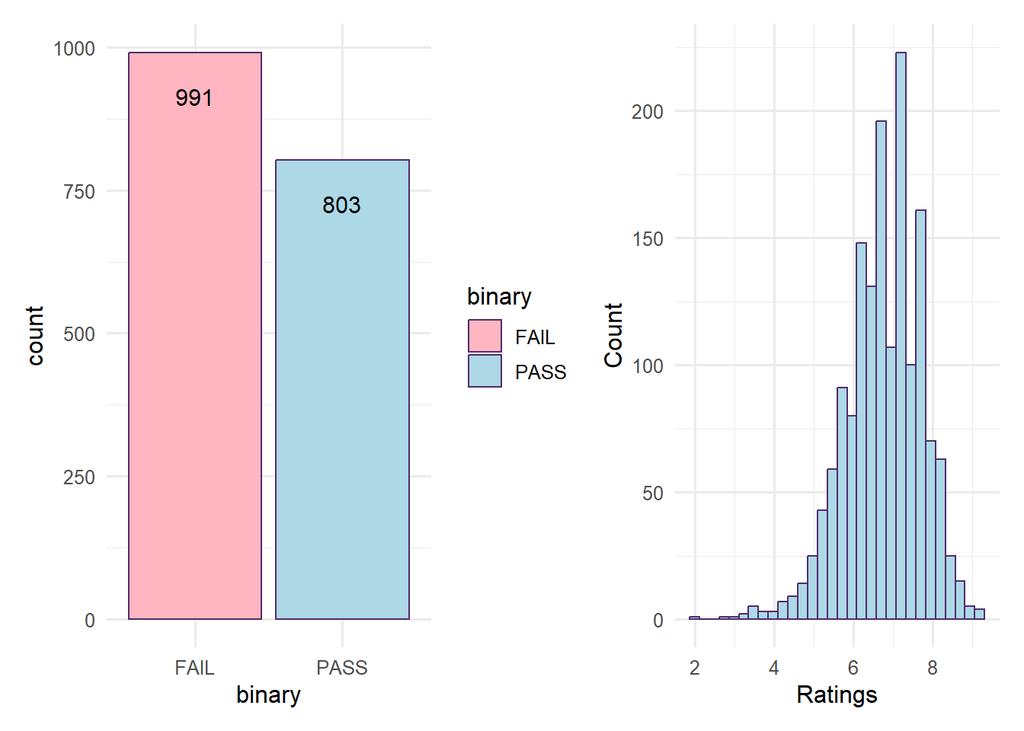

Figure 2: Exploratory plots for the number of movies that passed and fail the Bechdel Test and the distribution of IMDB ratings

```r
ra_2 <- movies %>%
  ggplot(aes(x=imdb_rating)) +
  geom_histogram(color="#512d6d",fill="lightblue") +
  xlab("Ratings") +
  ylab("Count") +
  theme(legend.position = "none")

(ra_1 + ra_2)
```

In the data-set, more movies fail than pass. Most movies have IMDB ratings between 6 and 8.

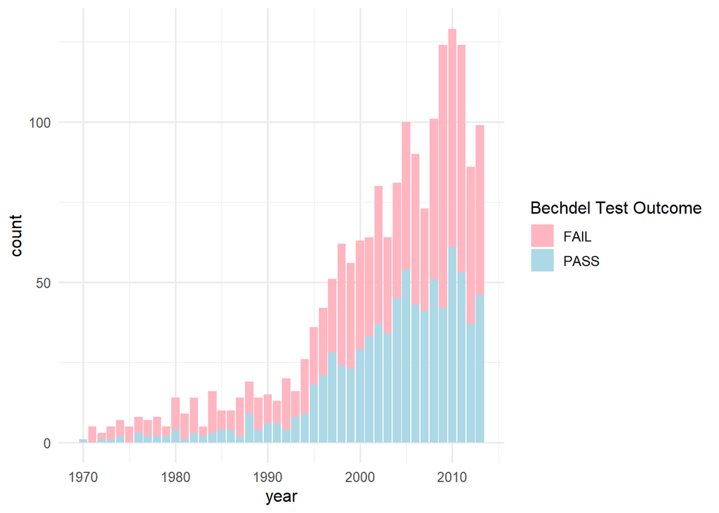

Figure 3: Exploratory stacked bar plot of the distribution of movies that passed and failed the Bechdel Test over the years.

```r
ggplot(movies, aes(x=year, fill=binary)) +
  geom_bar(position = "stack") +
  scale_fill_manual(values = c("lightpink","lightblue")) +
  labs(
    fill="Bechdel Test Outcome"
  )
```

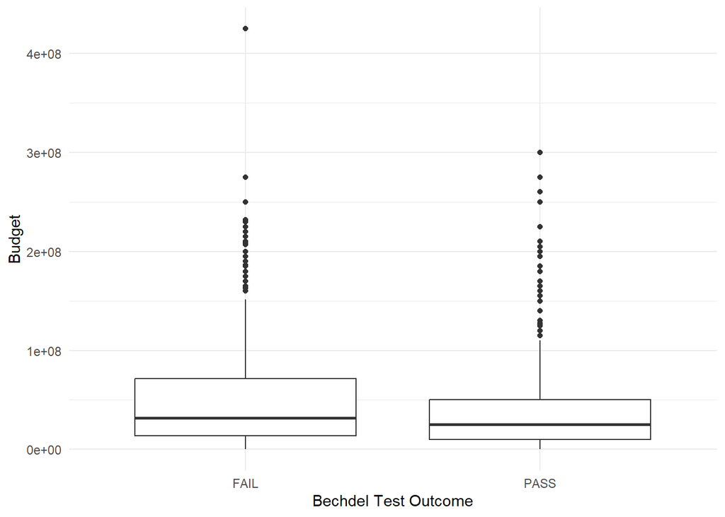

Figure 4: Box plot of the distribution of movie budgets of those that passed and failed with outliers, means, and quartiles.

```r
ggplot(movies, aes(x = binary, y = budget)) +
  labs(x = "Bechdel Test Outcome",
       y = "Budget") +
  geom_boxplot() +
  theme_minimal()
```

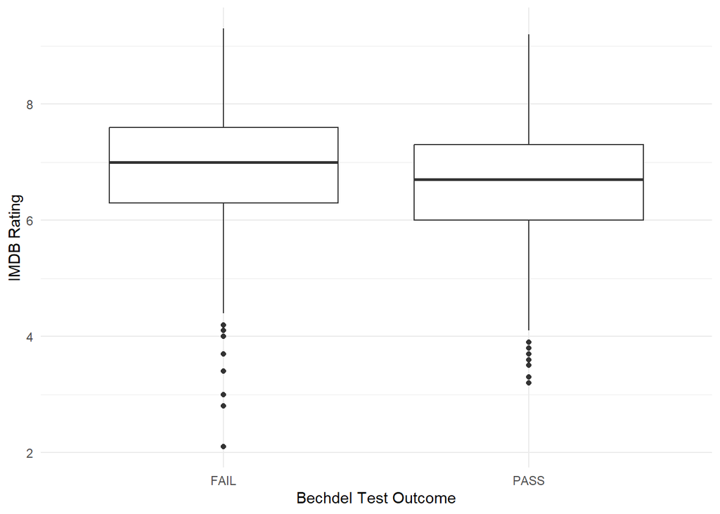

Figure 5: Box plot of the distribution of movie ratings of those that passed and failed with outliers, means, and quartiles

```r
ggplot(movies, aes(x = binary, y = imdb_rating)) +
  labs(x = "Bechdel Test Outcome",
       y = "IMDB Rating") +
  geom_boxplot() +
  theme_minimal()
```

Average ratings for both pass and fail fall between 6-8 and there is no clear evidence that rating has an impact on pass and fail rates.

```r
movies_sorted_genre <- movies %>%
  separate_rows(genre, sep = ", ")
```

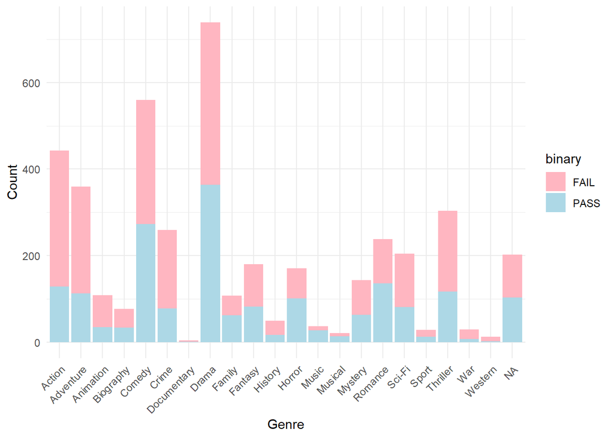

Figure 6: Stacked bar plot of the distribution of movies that passed and failed by genre.

```r
movies_sorted_genre %>%
  group_by(genre, binary) %>%
  summarise(count = n()) %>%
  ggplot(aes(x = genre, y = count, fill= binary)) +
  geom_bar(stat = "identity") +
 scale_fill_manual(values = c("PASS" = "lightblue", "FAIL" = "lightpink")) +

  xlab("Genre") +
  ylab("Count") +
   theme_minimal() +
  theme(axis.text.x = element_text(angle = 45, hjust = 1))
```

```r
summary_data <- movies_sorted_genre %>%
  group_by(genre, binary) %>%
  summarise(count = n())


genres_with_more_passing <- summary_data %>%
  spread(binary, count, fill = 0) %>%
  filter(PASS > FAIL)


cat("Genres with more passing movies than failing movies:\n")
```

```
Genres with more passing movies than failing movies:
```

```r
cat(genres_with_more_passing$genre, sep = "\n")
```

```
Family
Horror
Music
Musical
Romance
NA
```

The genres listed above are the genres that have more movies that pass than fail.

```r
movies_pass<- movies %>%
  filter(binary == "PASS")
```

```r
movies_fail <- movies %>%
  filter(binary == "FAIL")
```

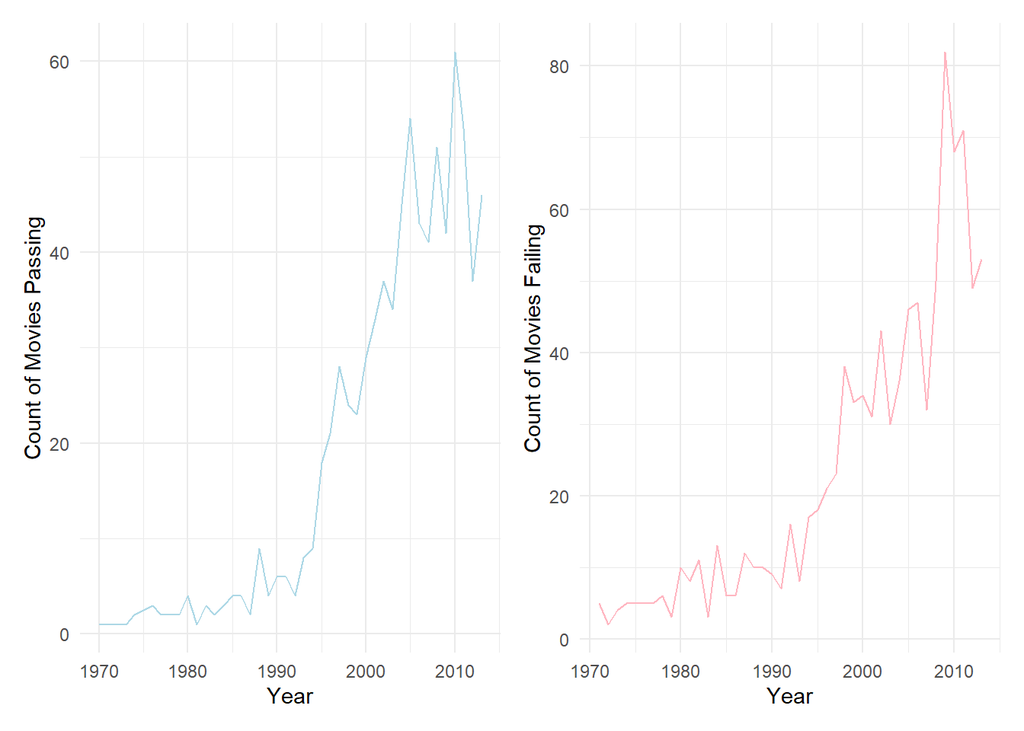

Figure 7: Line plots of the count of movies passing and failing over the years.

```r
pass<- ggplot(movies_pass, aes(x = year)) +
  geom_line(stat = "count", color = "lightblue") +
  xlab("Year") +
  ylab("Count of Movies Passing") +
  theme_minimal()

fail<- ggplot(movies_fail, aes(x = year)) +
  geom_line(stat = "count", color = "lightpink") +
  xlab("Year") +
  ylab("Count of Movies Failing") +
  theme_minimal()

(pass + fail)
```

Both passing and failing have seen increases in the count of movies but this is mostly due to the overall increase production of movies. Around 2010, both passing and failing were at a peak but have since seen significant drops but of recent both seem to be slowly rising.

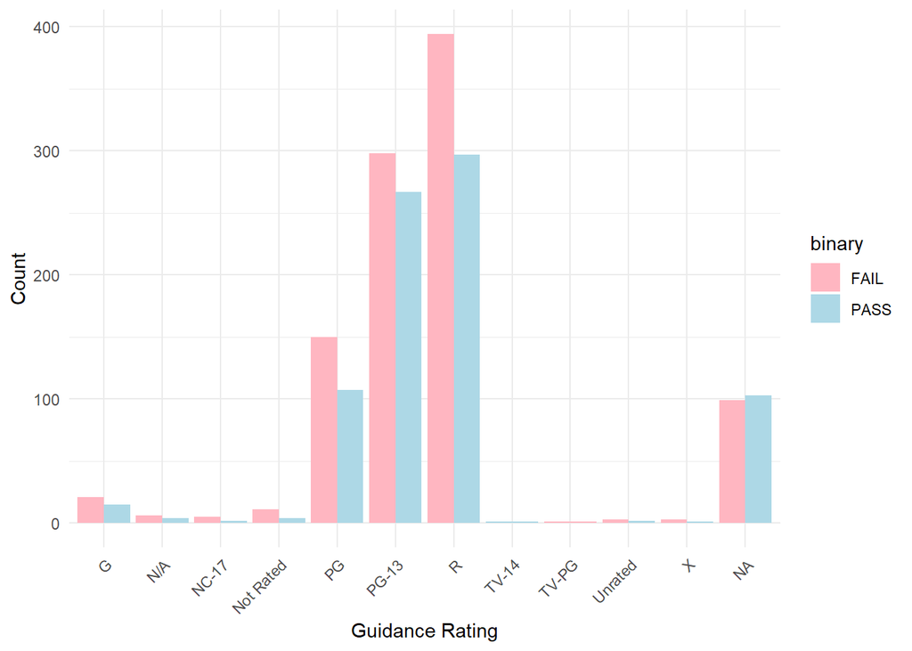

Figure 8: Grouped bar plot of the count of movies passing and failing grouped by guidance rating.

```r
ggplot(movies, aes(x = rated, fill = binary)) +
  geom_bar(position = "dodge") +
  xlab("Guidance Rating") +
  ylab("Count") +
  scale_fill_manual(values = c("PASS" = "lightblue", "FAIL" = "lightpink")) +
  theme_minimal() +
  theme(axis.text.x = element_text(angle = 45, hjust = 1))
```

Based on guidance ratings, all ratings seem to have more failing than passing movies besides those that are not rated.

```r
movies_sorted_country<- movies %>%
  separate_rows(country, sep = ", ")
```

```r
top_countries <- movies_sorted_country %>%
  filter(!is.na(country)) %>%
  group_by(country) %>%
  summarise(movie_count = n()) %>%
  arrange(desc(movie_count)) %>%
  head(5)
```

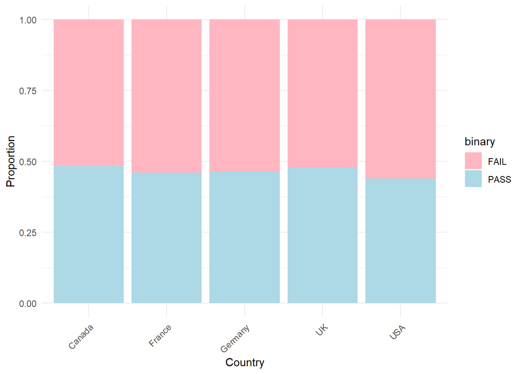

```r
#| label: fig-9
#| message: false
#| fig-cap: The top 5 producers of movies in the dataset and their proportion of failing/passing movies.

countries_of_interest <- c("USA", "UK", "Germany", "France", "Canada")

filtered_data <- movies_sorted_country %>%
  filter(country %in% countries_of_interest)

ggplot(filtered_data, aes(x = country, fill = binary)) +
  geom_bar(position = "fill") +
  xlab("Country") +
  ylab("Proportion") +
  scale_fill_manual(values = c("PASS" = "lightblue", "FAIL" = "lightpink")) +
  theme_minimal() +
  theme(axis.text.x = element_text(angle = 45, hjust = 1))
```

The top 5 country’s that produce the most movies in the dataset, all roughly seem to have even proportions of passing and failing movies. Some lean slightly more towards one that the other but it does not seem significant.

[figure not shown]

Figure 9: Grouped bar plot of pass and fail count by decade.

```r
labels <- c("1990s's", "2000's", "2010's")
ggplot(movies, aes(x = factor(decade_code), fill = binary)) +
  scale_x_discrete(labels = labels)+
  geom_bar(position = "dodge") +
  xlab("Decade") +
  ylab("Count") +
  scale_fill_manual(values = c("PASS" = "lightblue", "FAIL" = "lightpink")) +
  theme_minimal() +
  theme(axis.text.x = element_text(angle = 45, hjust = 1))
```

Based on decades, of all decades listed, more movies fail than pass.